### 331-70 Final Project

#### Ajay Patel, Ethan Moore, and Jack Langston

##### Intro

For our project, we decided to create a Shiny app to visualize the results of the 2018 Major League Baseball Postseason. Our app allows users to interact with the data we downloaded from BaseballSavant.com. The dataset includes dozens of variables for each of the approximately 10,000 pitches from the postseason, including pitch type, whether or not the ball was hit, what event occurred as a result of the hit, etc.

The work on this project was collaborative with each of the group members contributing equal amounts in a variety of ways. Without all three members, this project would have looked much different and would have been much worse.

### Example 1

Let’s look into how Yankee slugger Aaron Judge did against changeups thrown by the rival Red Sox:

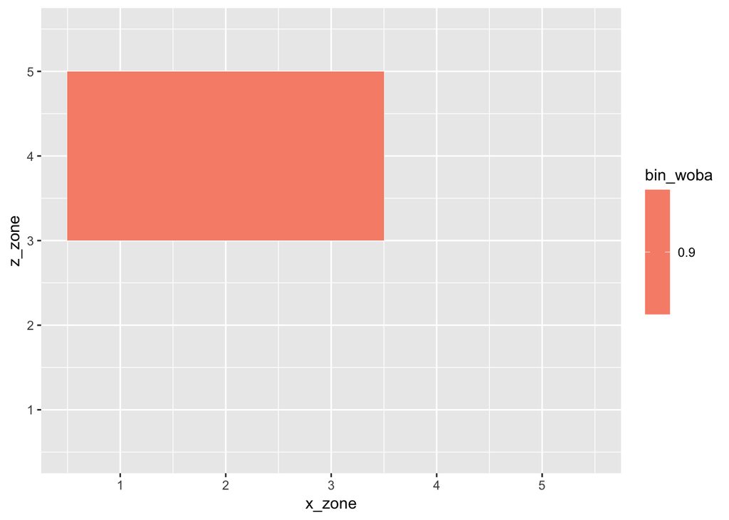

This graph shows that Judge saw changeups against the Red Sox in two regions, both high and inside, and had the same results on all of them. A wOBA of 0.9 is very good considering the average wOBA for a player in the postseason this year was 0.296.

### Example 2

In the National League, the Los Angeles Dodgers made it all the way to the World Series, in part due to their mid-season acquisition of third-baseman Manny Machado.

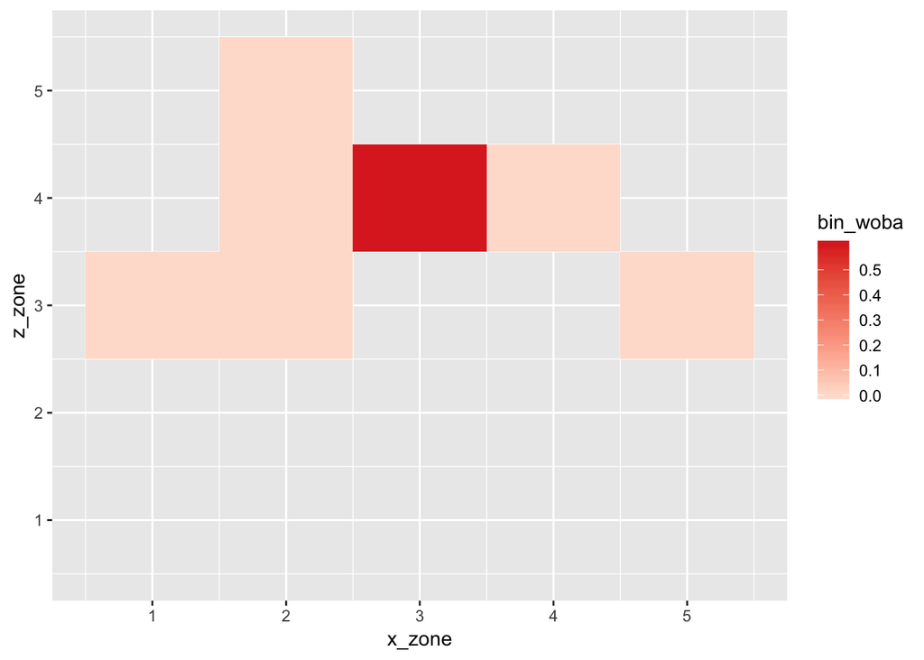

In World Series games (against the Red Sox), this graph shows how Machado did against 4-seam fastballs. He saw fastballs in seven different zones, getting a hit in only one zone, unsurprisingly in the most central zones where fastballs are often the easiest to hit.

If users select a combination of inputs that had 0 occurences, the graph will disappear and text will appear in the main panel prompting the user to select different inputs.